# Final project

Abdulaziz Bokijonov

## Research Question

My research data is student alcohol consumption. This dataset has columns indicating school, sex, age, family size, parents cohabitation status, mothers and fathers education, travel time from home to school, and number of past classes failed and etc. for all cases, which are students.

In addition to this data set, there is one more about life expectancy. Cases are countries from 2000 till 2015 followed by data about life expectancy, alcohol, deaths and etc.

Using this data I want to find if there is any correlation between those variables and the alcohol consumption of students. Which factors influence the alcoholism among students the most, does alcohol influence the school work, do some combination of variables cause more alcoholism and does it change over time? Does alcohol effects mortality? Any other interesting trends and correlations will be addressed as well.

It is an interesting research, because as a college student I am eager to learn the insights of my own college life and what factors influence it and what are results I might expect from it, although the data is from Portuguese institution. Also, from the second data set, I want to see how badly does alcohol affect life expectancy and overall health. Moreover, this research can prevent death or sicknesses from intoxication after finding out the causes of alcohol consumption.

## Data Processing

#### Data Intake

```r
library(tidyverse)
library(dcData)
DataTable <- read.csv("student-alcohol-consumption.csv")
DataTableLife <- read.csv("Life Expectancy Data.csv")
head(DataTable)
```

|  | school | sex | age | address | famsize | Pstatus | Medu | Fedu | Mjob | Fjob | reason | guardian | traveltime | studytime | failures | schoolsup | famsup | paid | activities | nursery | higher | internet | romantic | famrel | freetime | goout | Dalc | Walc | health | … |
| --- | --- | --- | --- | --- | --- | --- | --- | --- | --- | --- | --- | --- | --- | --- | --- | --- | --- | --- | --- | --- | --- | --- | --- | --- | --- | --- | --- | --- | --- | --- |
| 1 | GP | F | 18 | U | GT3 | A | 4 | 4 | at_home | teacher | course | mother | 2 | 2 | 0 | yes | no | no | no | yes | yes | no | no | 4 | 3 | 4 | 1 | 1 | 3 | … |
| 2 | GP | F | 17 | U | GT3 | T | 1 | 1 | at_home | other | course | father | 1 | 2 | 0 | no | yes | no | no | no | yes | yes | no | 5 | 3 | 3 | 1 | 1 | 3 | … |
| 3 | GP | F | 15 | U | LE3 | T | 1 | 1 | at_home | other | other | mother | 1 | 2 | 3 | yes | no | yes | no | yes | yes | yes | no | 4 | 3 | 2 | 2 | 3 | 3 | … |
| 4 | GP | F | 15 | U | GT3 | T | 4 | 2 | health | services | home | mother | 1 | 3 | 0 | no | yes | yes | yes | yes | yes | yes | yes | 3 | 2 | 2 | 1 | 1 | 5 | … |
| 5 | GP | F | 16 | U | GT3 | T | 3 | 3 | other | other | home | father | 1 | 2 | 0 | no | yes | yes | no | yes | yes | no | no | 4 | 3 | 2 | 1 | 2 | 5 | … |
| 6 | GP | M | 16 | U | LE3 | T | 4 | 3 | services | other | reputation | mother | 1 | 2 | 0 | no | yes | yes | yes | yes | yes | yes | no | 5 | 4 | 2 | 1 | 2 | 5 | … |

```r
head(DataTableLife)
```

|  | Country | Year | Status | Life.expectancy | Adult.Mortality | infant.deaths | Alcohol | percentage.expenditure | Hepatitis.B | Measles | BMI | under.five.deaths | Polio | Total.expenditure | Diphtheria | HIV.AIDS | GDP | Population | thinness..1.19.years | thinness.5.9.years | Income.composition.of.resources | Schooling |
| --- | --- | --- | --- | --- | --- | --- | --- | --- | --- | --- | --- | --- | --- | --- | --- | --- | --- | --- | --- | --- | --- | --- |
| 1 | Afghanistan | 2015 | Developing | 65.0 | 263 | 62 | 0.01 | 71.279624 | 65 | 1154 | 19.1 | 83 | 6 | 8.16 | 65 | 0.1 | 584.25921 | 33736494 | 17.2 | 17.3 | 0.479 | 10.1 |
| 2 | Afghanistan | 2014 | Developing | 59.9 | 271 | 64 | 0.01 | 73.523582 | 62 | 492 | 18.6 | 86 | 58 | 8.18 | 62 | 0.1 | 612.69651 | 327582 | 17.5 | 17.5 | 0.476 | 10.0 |
| 3 | Afghanistan | 2013 | Developing | 59.9 | 268 | 66 | 0.01 | 73.219243 | 64 | 430 | 18.1 | 89 | 62 | 8.13 | 64 | 0.1 | 631.74498 | 31731688 | 17.7 | 17.7 | 0.470 | 9.9 |
| 4 | Afghanistan | 2012 | Developing | 59.5 | 272 | 69 | 0.01 | 78.184215 | 67 | 2787 | 17.6 | 93 | 67 | 8.52 | 67 | 0.1 | 669.95900 | 3696958 | 17.9 | 18.0 | 0.463 | 9.8 |
| 5 | Afghanistan | 2011 | Developing | 59.2 | 275 | 71 | 0.01 | 7.097109 | 68 | 3013 | 17.2 | 97 | 68 | 7.87 | 68 | 0.1 | 63.53723 | 2978599 | 18.2 | 18.2 | 0.454 | 9.5 |
| 6 | Afghanistan | 2010 | Developing | 58.8 | 279 | 74 | 0.01 | 79.679367 | 66 | 1989 | 16.7 | 102 | 66 | 9.20 | 66 | 0.1 | 553.32894 | 2883167 | 18.4 | 18.4 | 0.448 | 9.2 |

To use the data, I just downloaded the data csv files from Kaggle website and used read.csv function to import them into the r environment.

In the first dataset, the cases are student and here are the key variables:

- school: The educational institution the student attends (categorical: “GP” - Gabriel Pereira, “MS” - Mousinho da Silveira).
- sex: The gender of the student (categorical: “F” - female, “M” - male).
- age: The age of the student (quantitative: 15-22 years old).
- famsize: The size of the student’s family (categorical: “GT3” - more than 3, “LE3” - 3 or fewer members).
- Pstatus: The living arrangement of the student’s parents (categorical: “T” - living together, “A” - living apart).
- Medu: The educational level of the student’s mother (quantitative: 0-4, representing different levels of education).
- Fedu: The educational level of the student’s father (quantitative: 0-4, representing different levels of education).
- traveltime: The duration of travel from home to school (quantitative: 1-4, representing different time levels).
- failures: The number of previous class failures (quantitative: 0-4).
- Dalc: Alcohol consumption on workdays (quantitative: 1-5, ranging from very low to very high).
- Walc: Alcohol consumption on weekends (quantitative: 1-5, ranging from very low to very high).
- health: The student’s current health status (quantitative: 1-5, ranging from very bad to very good).
- absences: The number of school absences (quantitative: 0-93).
- G3: The final grade achieved by the student (quantitative: 0-20).

Potential outliers of this data can be people who are acing both alcoholism and academics, because I suppose alcoholism would be negatively reflected on the academics

In the second data set, cases are countries from 2000 till 2015 followed by these key variables:

- country (categorical)
- year (quantitative: year of data collection)
- Life expectancy (quantitative),
- Alcohol: Quantitative variable representing the recorded per capita (15+) consumption of alcohol in litres of pure alcohol.
- Adult Mortality Rates: Quantitative variable representing the probability of dying between 15 and 60 years per 1000 population for both sexes.

The ourliers for this data set can be countries that don’t have high quality of life, thus more mortality rate not related to alcohol.

#### Data Wrangling

```r
# Find the most popular value in the column
MostPopularVal <- function(x) {
  ux <- unique(x)
  ux[which.max(tabulate(match(x, ux)))]
}

# Groups the data frame by totalAlc and find mean for numbers and most popular value for characters
GroupEverything <- function(dataSet) {
  ToReturn <- dataSet %>%
    group_by(totalAlc) %>%
    summarise(school = MostPopularVal(school))
  for (i in 2:(ncol(dataSet)-1)){
     varType <- class(dataSet[,i])
     if(as.character(varType) == "character"){
      tempData <- dataSet %>%
        group_by(totalAlc) %>%
        summarise(
          MostPopularVal(eval(parse(text = paste(names(dataSet)[i]))))
        )
     }
     else{
      tempData <- dataSet %>%
        group_by(totalAlc) %>%
        summarise(
          mean(eval(parse(text = paste(names(dataSet)[i]))))
        )
     }

     ToReturn <- merge(ToReturn, tempData)
     names(ToReturn)[length(names(ToReturn))] <- names(dataSet)[i]

  }
  return(ToReturn)
}

# Adds workday and weekend alcohol using mutate
AlcoholTotal <-
  DataTable %>%
  mutate(totalAlc = Dalc+Walc)

# Gets all grouped table
StudentsGroupedTotalAlc <-GroupEverything(AlcoholTotal)
StudentsGroupedTotalAlc
```

| totalAlc | school | sex | age | address | famsize | Pstatus | Medu | Fedu | Mjob | Fjob | reason | guardian | traveltime | studytime | failures | schoolsup | famsup | paid | activities | nursery | higher | internet | romantic | famrel | freetime | goout | Dalc | Walc | health | … |
| --- | --- | --- | --- | --- | --- | --- | --- | --- | --- | --- | --- | --- | --- | --- | --- | --- | --- | --- | --- | --- | --- | --- | --- | --- | --- | --- | --- | --- | --- | --- |
| 2 | GP | F | 16.45333 | U | GT3 | T | 2.813333 | 2.526667 | other | other | course | mother | 1.380000 | 2.293333 | 0.2533333 | no | yes | no | yes | yes | yes | yes | no | 4.066667 | 3.160000 | 2.740000 | 1.000000 | 1.000000 | 3.433333 | … |
| 3 | GP | F | 16.77273 | U | GT3 | T | 2.681818 | 2.484848 | other | other | course | mother | 1.424242 | 2.000000 | 0.1969697 | no | yes | yes | no | yes | yes | yes | no | 4.015152 | 2.924242 | 2.848485 | 1.015152 | 1.984848 | 3.515152 | … |
| 4 | GP | M | 16.91667 | U | GT3 | T | 2.766667 | 2.533333 | other | other | reputation | mother | 1.350000 | 2.000000 | 0.3333333 | no | yes | yes | yes | yes | yes | yes | no | 3.850000 | 3.266667 | 3.116667 | 1.300000 | 2.700000 | 3.516667 | … |
| 5 | GP | F | 16.64444 | U | GT3 | T | 2.733333 | 2.711111 | services | other | home | mother | 1.533333 | 1.911111 | 0.2888889 | no | yes | no | no | yes | yes | yes | no | 3.711111 | 3.333333 | 3.311111 | 1.688889 | 3.311111 | 3.577778 | … |
| 6 | GP | M | 17.05714 | U | GT3 | T | 2.371429 | 2.285714 | other | other | course | mother | 1.571429 | 1.657143 | 0.8000000 | no | yes | no | no | yes | yes | yes | no | 3.828571 | 3.400000 | 3.942857 | 2.171429 | 3.828571 | 3.914286 | … |
| 7 | GP | M | 16.82353 | U | GT3 | T | 3.117647 | 2.470588 | services | services | course | mother | 1.529412 | 1.470588 | 0.6470588 | no | no | no | no | yes | yes | yes | no | 3.941176 | 3.705882 | 3.764706 | 2.764706 | 4.235294 | 3.941176 | … |
| 8 | GP | M | 16.22222 | U | LE3 | T | 3.111111 | 2.888889 | other | other | reputation | mother | 1.666667 | 1.777778 | 0.3333333 | no | no | yes | yes | yes | yes | yes | no | 3.777778 | 3.444444 | 4.222222 | 3.333333 | 4.666667 | 3.444444 | … |
| 9 | GP | M | 18.00000 | U | LE3 | T | 2.250000 | 2.250000 | at_home | services | course | other | 2.000000 | 2.000000 | 0.5000000 | no | yes | yes | yes | yes | yes | yes | no | 4.500000 | 3.750000 | 3.750000 | 4.000000 | 5.000000 | 3.750000 | … |
| 10 | GP | M | 17.22222 | U | GT3 | T | 2.777778 | 2.444444 | services | services | home | mother | 1.888889 | 1.666667 | 0.4444444 | no | yes | no | yes | no | yes | yes | yes | 3.555556 | 4.111111 | 4.222222 | 5.000000 | 5.000000 | 3.888889 | … |

```r
# Alcohol consumption and failed classes count
AlcoholFClasses <-
  DataTable %>%
  group_by(failures) %>%
  summarise(meanAlcWeekday = mean(Dalc),
            meanAlcWeekend = mean(Walc))
head(AlcoholFClasses)
```

| failures | meanAlcWeekday | meanAlcWeekend |
| --- | --- | --- |
| 0 | 1.416667 | 2.205128 |
| 1 | 1.680000 | 2.500000 |
| 2 | 1.764706 | 2.647059 |
| 3 | 1.812500 | 2.937500 |

```r
# Alcohol consumption and age
AlcoholAge <-
  DataTable %>%
  group_by(age) %>%
  summarise(meanAlcWeekday = mean(Dalc),
            meanAlcWeekend = mean(Walc))
head(AlcoholAge)
```

| age | meanAlcWeekday | meanAlcWeekend |
| --- | --- | --- |
| 15 | 1.353659 | 1.902439 |
| 16 | 1.432692 | 2.278846 |
| 17 | 1.520408 | 2.571429 |
| 18 | 1.548780 | 2.414634 |
| 19 | 1.458333 | 1.958333 |
| 20 | 2.000000 | 2.333333 |

```r
# Alcohol consumption and life expectancy with deaths
AlcoholLife <- DataTableLife %>%
  group_by(Alcohol) %>%
  filter(Status == "Developed")
head(AlcoholLife)
```

| Country | Year | Status | Life.expectancy | Adult.Mortality | infant.deaths | Alcohol | percentage.expenditure | Hepatitis.B | Measles | BMI | under.five.deaths | Polio | Total.expenditure | Diphtheria | HIV.AIDS | GDP | Population | thinness..1.19.years | thinness.5.9.years | Income.composition.of.resources | Schooling |
| --- | --- | --- | --- | --- | --- | --- | --- | --- | --- | --- | --- | --- | --- | --- | --- | --- | --- | --- | --- | --- | --- |
| Australia | 2015 | Developed | 82.8 | 59 | 1 | NA | 0.000 | 93 | 74 | 66.6 | 1 | 93 | NA | 93 | 0.1 | 56554.39 | 23789338 | 0.6 | 0.6 | 0.937 | 20.4 |
| Australia | 2014 | Developed | 82.7 | 6 | 1 | 9.71 | 10769.363 | 91 | 340 | 66.1 | 1 | 92 | 9.42 | 92 | 0.1 | 62214.69 | 2346694 | 0.6 | 0.6 | 0.936 | 20.4 |
| Australia | 2013 | Developed | 82.5 | 61 | 1 | 9.87 | 11734.854 | 91 | 158 | 65.5 | 1 | 91 | 9.36 | 91 | 0.1 | 67792.34 | 23117353 | 0.6 | 0.6 | 0.933 | 20.3 |
| Australia | 2012 | Developed | 82.3 | 61 | 1 | 10.03 | 11714.999 | 91 | 199 | 65.0 | 1 | 92 | 9.36 | 92 | 0.1 | 67677.63 | 22728254 | 0.6 | 0.6 | 0.930 | 20.1 |
| Australia | 2011 | Developed | 82.0 | 63 | 1 | 10.30 | 10986.265 | 92 | 190 | 64.4 | 1 | 92 | 9.20 | 92 | 0.1 | 62245.13 | 223424 | 0.6 | 0.6 | 0.927 | 19.8 |
| Australia | 2010 | Developed | 81.9 | 64 | 1 | 10.52 | 8875.786 | 92 | 70 | 63.9 | 1 | 92 | 9.20 | 92 | 0.1 | 51874.85 | 223175 | 0.7 | 0.6 | 0.927 | 19.5 |

```r
NA
```

## Data Visualization

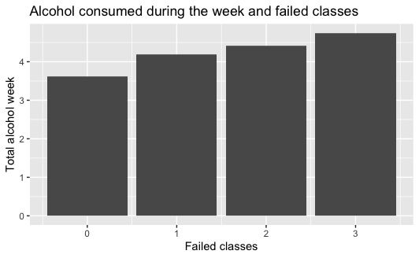

```r
AlcoholFClasses %>%
  ggplot(aes(x=failures,y=(meanAlcWeekday+meanAlcWeekend))) +
  geom_bar(stat='identity',position='stack', width=.9) +
  labs(y= "Total alcohol week", x = "Failed classes") +
  ggtitle("Alcohol consumed during the week and failed classes")
```

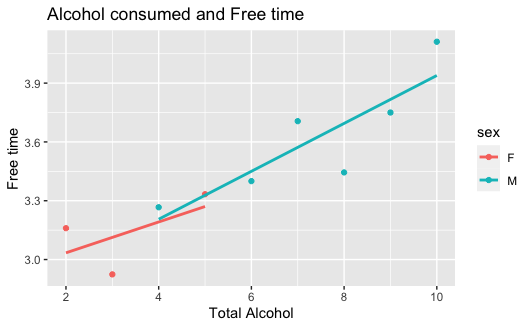

```r
StudentsGroupedTotalAlc %>%
  ggplot(aes(x=totalAlc,y=freetime, color=sex)) +
  geom_point() +
  geom_smooth(method='lm', se = FALSE) +
  labs(y= "Free time", x = "Total Alcohol") +
  ggtitle("Alcohol consumed and Free time")
```

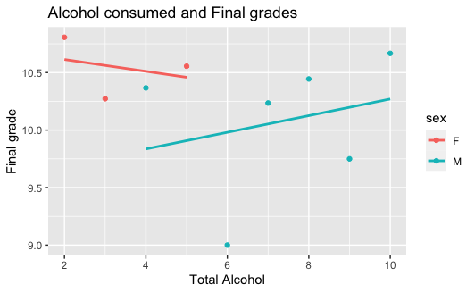

```r
StudentsGroupedTotalAlc %>%
  ggplot(aes(x=totalAlc,y=G3, color=sex)) +
  geom_point() +
  geom_smooth(method='lm', se = FALSE) +
  labs(y= "Final grade", x = "Total Alcohol") +
  ggtitle("Alcohol consumed and Final grades")
```

- In the first graph we see that the there is positive correlation between alcohol consumed and failed classes. This graph shows that more alcohol consumed, more classes failed.
- In the second graph, we can see the relation of free time and alcohol consumed. Both for females and males, more free time correlates with more alcohol consumed. This can be both cause and effect of alacohol consumption.
- In the third graph we can see the final grades relation to the total alcohol consumed. For females alcohol consumption negatively relates to grades, meaning that the more alcohol consumed, the lower the final grades. For males its the opposite, alcohol consumtion have positive relation with their final grades.

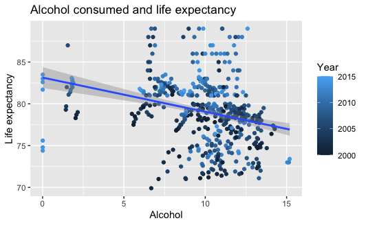

```r
AlcoholLife %>%
  ggplot(aes(x=Alcohol,y=Life.expectancy, color=Year)) +
  geom_point() +
  geom_smooth(method='lm', formula= y~x) +
  labs(y= "Life expectancy", x = "Alcohol") +
  ggtitle("Alcohol consumed and life expectancy")
```

[figure not shown]

```r
AlcoholLife %>%
  ggplot(aes(x=Alcohol,y=BMI, color=Year)) +
  geom_point() +
  geom_smooth(method='lm', formula= y~x) +
  labs(y= "BMI", x = "Life expectancy") +
  ggtitle("Alcohol consumed and BMI")
```

The second dataset’s countries were filtered to only Developed contries to avoid outliers.

- In the first graph, based on the best fit line, there is a negative relation between alcohol consumed and life expectancy. More alcohol consumed, lower the life expectancy.
- In the second graph, BMI (body mass index) positively relates to alcohol consumed. Its higher when more alcohol is consumed. P.S., high can cause health problems and decrease life expectancy.

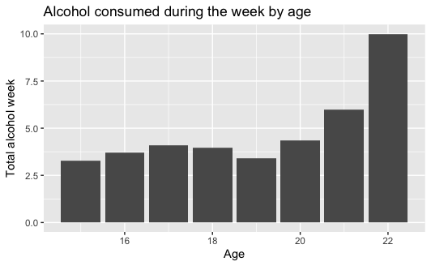

```r
AlcoholAge %>%
  ggplot(aes(x=age,y=(meanAlcWeekday+meanAlcWeekend))) +
  geom_bar(stat='identity',position='stack', width=.9) +
  labs(y= "Total alcohol week", x = "Age") +
  ggtitle("Alcohol consumed during the week by age")
```

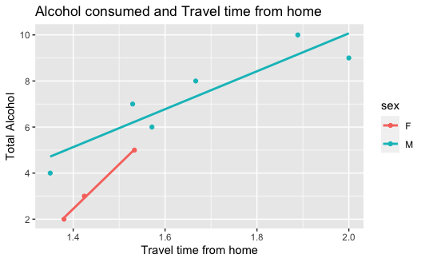

```r
StudentsGroupedTotalAlc %>%
  ggplot(aes(y=totalAlc,x=traveltime, color=sex)) +
  geom_point() +
  geom_smooth(method='lm', se = FALSE) +
  labs(x= "Travel time from home", y = "Total Alcohol") +
  ggtitle("Alcohol consumed and Travel time from home")
```

[figure not shown]

```r
StudentsGroupedTotalAlc %>%
  ggplot(aes(y=totalAlc,x=health, color=sex)) +
  geom_point() +
  geom_smooth(method='lm', se = FALSE) +
  labs(x= "Health", y = "Total Alcohol") +
  ggtitle("Alcohol consumed and Final grades")
```

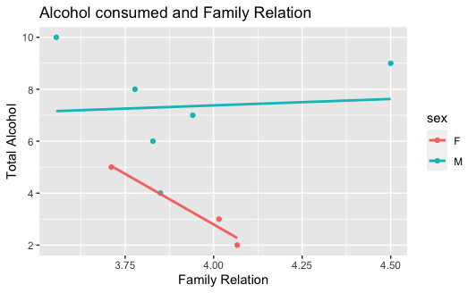

```r
StudentsGroupedTotalAlc %>%
  ggplot(aes(y=totalAlc,x=famrel, color=sex)) +
  geom_point() +
  geom_smooth(method='lm', se = FALSE) +
  labs(x= "Family Relation", y = "Total Alcohol") +
  ggtitle("Alcohol consumed and Family Relation")
```

In this section we are trying to indentify the “cause” of alcohol consumtion, at lest the variables that have positive relation with it.